# Allegheny Woodrat Occupancy

Robert Windham

2023-10-02

# Allegheny Woodrat

This data documents the regional occupancy of Allegheny Woodrat (*Neotoma magister*) across western Virginia. This species is listed as **Near Threatened** on the IUCN red list, and in Virginia, the Allegheny Woodrat is a species of greatest conservation need that has had drastic reductions in their geographic range in the past 40 years. For this data, the response variable is Woodrat presence or absence, and the predictor variables are elevation and distance to the nearest neighboring outcrop.

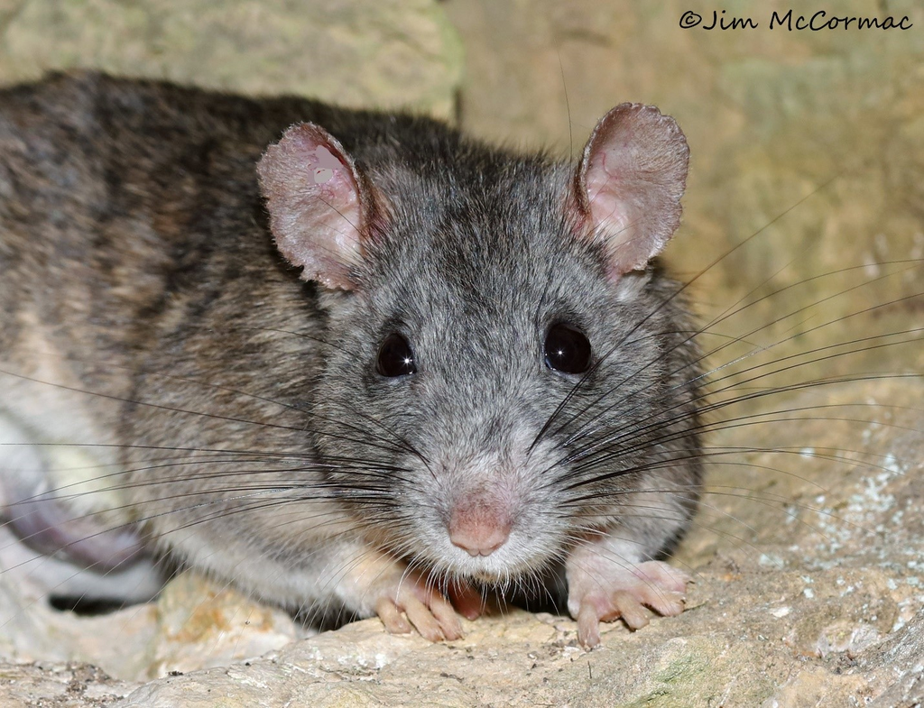

Figure 1. Allegheny Woodrat (*Neotoma magister*)

# Plots

## TN1 GLM Plot

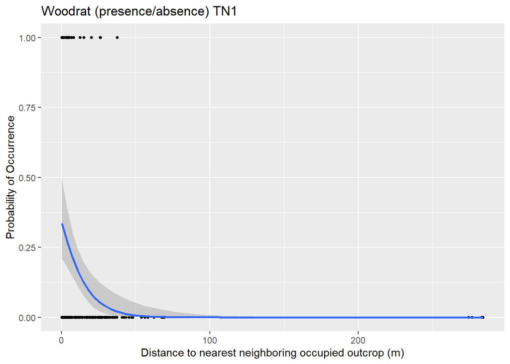

## TN2 GLM Plot

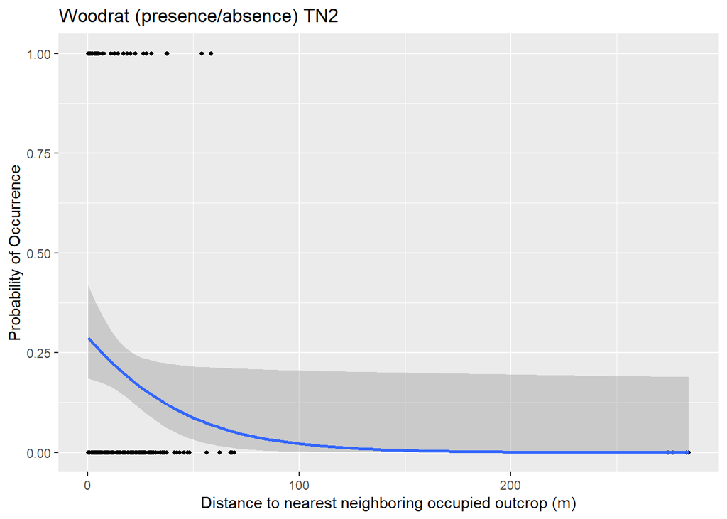

## TN3 GLM Plot

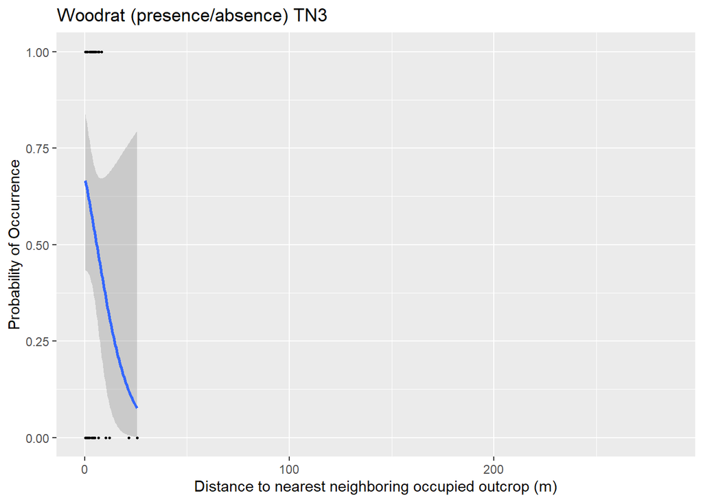

## TN4 GLM Plot

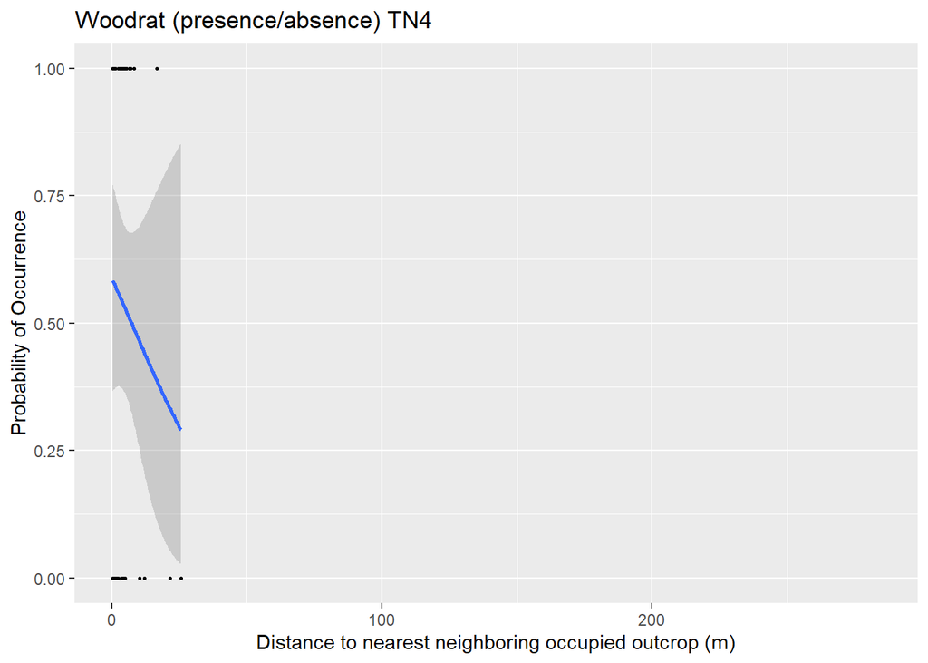

# Binomial and Quasibinomial summary models

## TN1 Summary

**GLM of TN1 ~ Isolation**

```
##
## Call:
## glm(formula = TN1 ~ Isolation, family = binomial, data = woodrat)
##
## Coefficients:
##             Estimate Std. Error z value Pr(>|z|)
## (Intercept)  -0.6558     0.3273    -2.0  0.04506 *
## Isolation    -0.0861     0.0246    -3.5  0.00047 ***
## ---
## Signif. codes:  0 '***' 0.001 '**' 0.01 '*' 0.05 '.' 0.1 ' ' 1
##
## (Dispersion parameter for binomial family taken to be 1)
##
##     Null deviance: 140.20  on 175  degrees of freedom
## Residual deviance: 120.55  on 174  degrees of freedom
## AIC: 124.6
##
## Number of Fisher Scoring iterations: 7
```

**Quasibinomial model**

```
##
## Call:
## glm(formula = TN1 ~ Isolation, family = quasibinomial, data = woodrat)
##
## Coefficients:
##             Estimate Std. Error t value Pr(>|t|)
## (Intercept)  -0.6558     0.3340   -1.96  0.05117 .
## Isolation    -0.0861     0.0251   -3.43  0.00076 ***
## ---
## Signif. codes:  0 '***' 0.001 '**' 0.01 '*' 0.05 '.' 0.1 ' ' 1
##
## (Dispersion parameter for quasibinomial family taken to be 1)
##
##     Null deviance: 140.20  on 175  degrees of freedom
## Residual deviance: 120.55  on 174  degrees of freedom
## AIC: NA
##
## Number of Fisher Scoring iterations: 7
```

## TN2 Summary

**GLM of TN2 ~ Isolation**

```
##
## Call:
## glm(formula = TN2 ~ Isolation, family = binomial, data = woodrat)
##
## Coefficients:
##             Estimate Std. Error z value Pr(>|z|)
## (Intercept)  -0.8999     0.2952   -3.05   0.0023 **
## Isolation    -0.0291     0.0145   -2.01   0.0449 *
## ---
## Signif. codes:  0 '***' 0.001 '**' 0.01 '*' 0.05 '.' 0.1 ' ' 1
##
## (Dispersion parameter for binomial family taken to be 1)
##
##     Null deviance: 172.76  on 175  degrees of freedom
## Residual deviance: 166.53  on 174  degrees of freedom
## AIC: 170.5
##
## Number of Fisher Scoring iterations: 6
```

**Quasibinomial model**

```
##
## Call:
## glm(formula = TN2 ~ Isolation, family = quasibinomial, data = woodrat)
##
## Coefficients:
##             Estimate Std. Error t value Pr(>|t|)
## (Intercept)  -0.8999     0.2974   -3.03   0.0029 **
## Isolation    -0.0291     0.0146   -1.99   0.0480 *
## ---
## Signif. codes:  0 '***' 0.001 '**' 0.01 '*' 0.05 '.' 0.1 ' ' 1
##
## (Dispersion parameter for quasibinomial family taken to be 1)
##
##     Null deviance: 172.76  on 175  degrees of freedom
## Residual deviance: 166.53  on 174  degrees of freedom
## AIC: NA
##
## Number of Fisher Scoring iterations: 6
```

## TN3 Summary

**GLM of TN3 ~ Isolation**

```
##
## Call:
## glm(formula = TN3 ~ Isolation, family = binomial, data = woodrat)
##
## Coefficients:
##             Estimate Std. Error z value Pr(>|z|)
## (Intercept)   0.7287     0.4978    1.46     0.14
## Isolation    -0.1259     0.0878   -1.43     0.15
##
## (Dispersion parameter for binomial family taken to be 1)
##
##     Null deviance: 48.263  on 34  degrees of freedom
## Residual deviance: 45.346  on 33  degrees of freedom
##   (141 observations deleted due to missingness)
## AIC: 49.35
##
## Number of Fisher Scoring iterations: 4
```

**Quasibinomial model**

```
##
## Call:
## glm(formula = TN3 ~ Isolation, family = quasibinomial, data = woodrat)
##
## Coefficients:
##             Estimate Std. Error t value Pr(>|t|)
## (Intercept)   0.7287     0.5063    1.44     0.16
## Isolation    -0.1259     0.0893   -1.41     0.17
##
## (Dispersion parameter for quasibinomial family taken to be 1)
##
##     Null deviance: 48.263  on 34  degrees of freedom
## Residual deviance: 45.346  on 33  degrees of freedom
##   (141 observations deleted due to missingness)
## AIC: NA
##
## Number of Fisher Scoring iterations: 4
```

## TN4 Summary

```
##
## Call:
## glm(formula = TN4 ~ Isolation, family = binomial, data = woodrat)
##
## Coefficients:
##             Estimate Std. Error z value Pr(>|z|)
## (Intercept)   0.3534     0.4504    0.78     0.43
## Isolation    -0.0488     0.0615   -0.79     0.43
##
## (Dispersion parameter for binomial family taken to be 1)
##
##     Null deviance: 49.795  on 35  degrees of freedom
## Residual deviance: 49.129  on 34  degrees of freedom
##   (140 observations deleted due to missingness)
## AIC: 53.13
##
## Number of Fisher Scoring iterations: 4
```

**Quasibinomial model**

```
##
## Call:
## glm(formula = TN4 ~ Isolation, family = quasibinomial, data = woodrat)
##
## Coefficients:
##             Estimate Std. Error t value Pr(>|t|)
## (Intercept)   0.3534     0.4630    0.76     0.45
## Isolation    -0.0488     0.0632   -0.77     0.45
##
## (Dispersion parameter for quasibinomial family taken to be 1.1)
##
##     Null deviance: 49.795  on 35  degrees of freedom
## Residual deviance: 49.129  on 34  degrees of freedom
##   (140 observations deleted due to missingness)
## AIC: NA
##
## Number of Fisher Scoring iterations: 4
```

# Binned Plots

## TN1 Plot

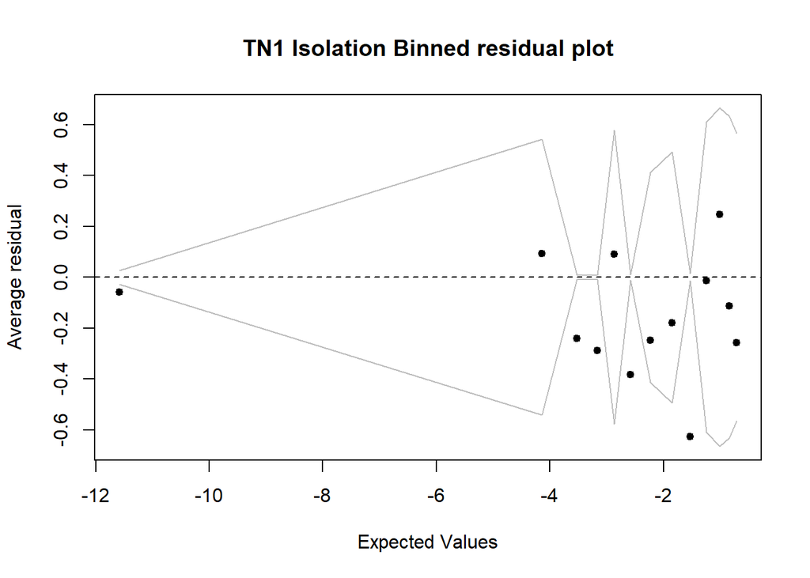

## TN2 Plot

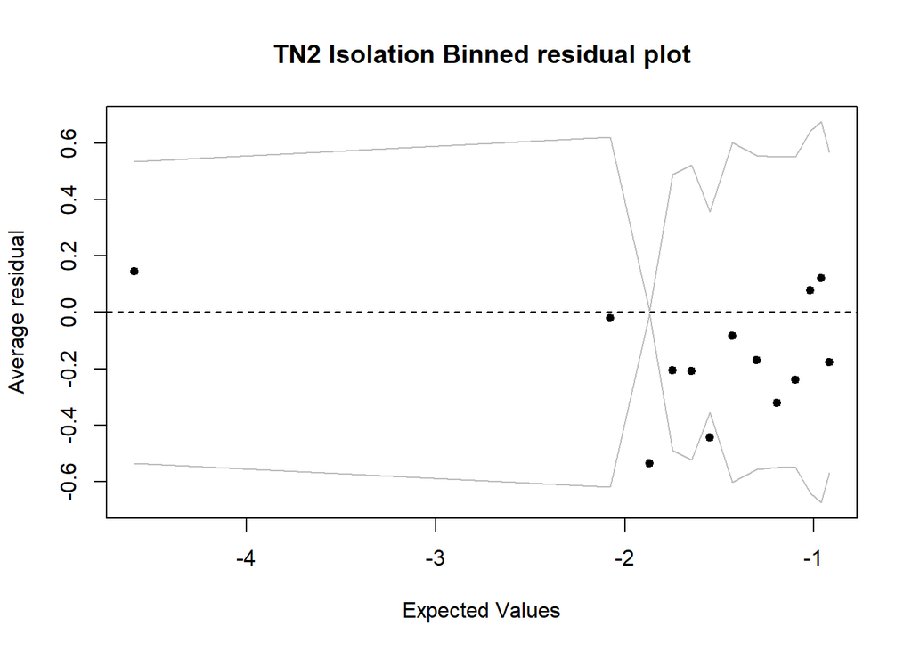

## TN3 Plot

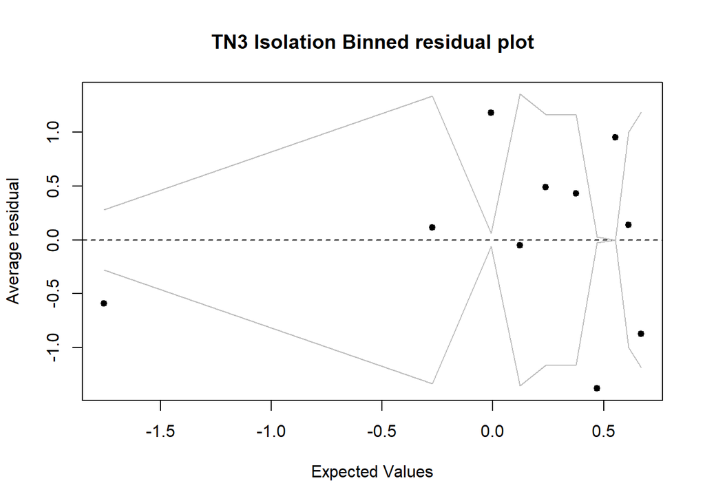

## TN4 Plot

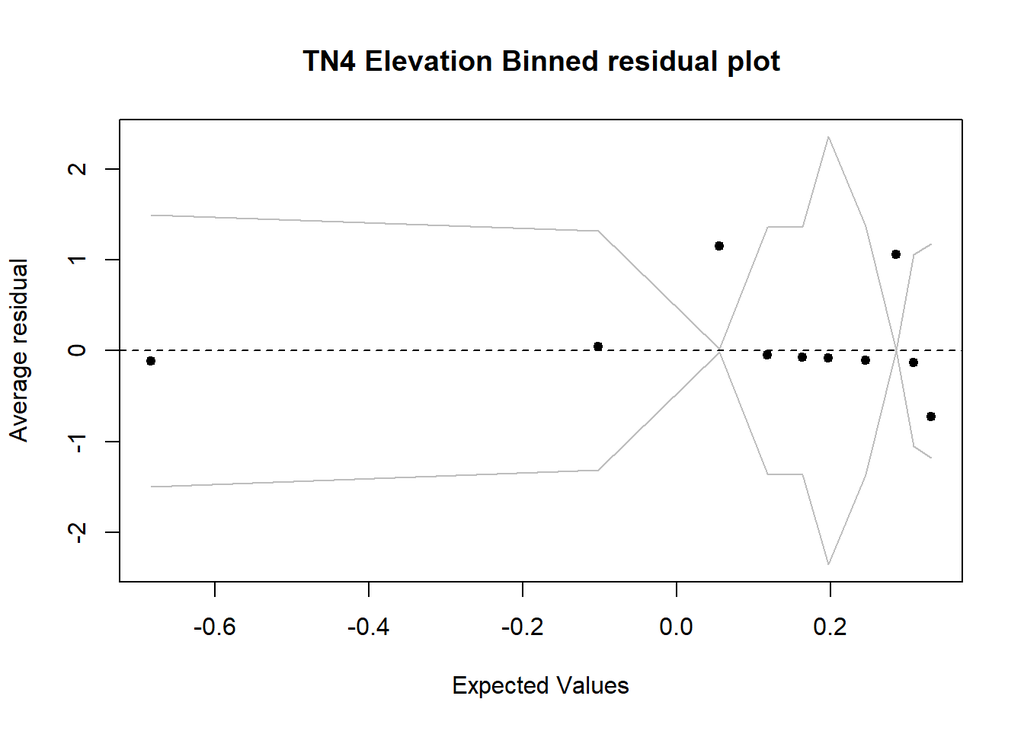

# Model Coefficients/Estimations

## Model 1

(TN1 ~ Isolation)

```
## (Intercept)   Isolation
##      -0.656      -0.086
```

```
##             2.5 % 97.5 %
## (Intercept) -1.33 -0.013
## Isolation   -0.14 -0.042
```

To estimate the maximum predicted effect on the response of a unit change in the predictor, we can divide -.086/4 = -.0215 ~ -2.15%. A difference in 1 unit of distance to nearest neighboring outcrop (m) corresponds to a decrease in the probability of Woodrat presence of 2.15%.

## Model 2

(TN2 ~ Isolation)

```
## (Intercept)   Isolation
##      -0.900      -0.029
```

```
##             2.5 %  97.5 %
## (Intercept) -1.49 -0.3283
## Isolation   -0.06 -0.0042
```

A difference in 1 unit of distance to nearest neighboring outcrop (m) corresponds to a decrease in the probability of Woodrat presence of .725%.

## Model 3

(TN3 ~ Isolation)

```
## (Intercept)   Isolation
##        0.73       -0.13
```

```
##             2.5 % 97.5 %
## (Intercept) -0.22  1.814
## Isolation   -0.35  0.019
```

A difference in 1 unit of unit of distance to nearest neighboring outcrop (m) corresponds to a decrease in the probability of Woodrat presence of 3.25%.

## Model 4

(TN4 ~ Isolation)

```
## (Intercept)   Isolation
##       0.353      -0.049
```

```
##             2.5 % 97.5 %
## (Intercept) -0.55  1.294
## Isolation   -0.19  0.071
```

A difference in 1 unit of distance to nearest neighboring outcrop (m) corresponds to a decrease in the probability of Woodrat presence of 1.23%